# Bayesian data analysis

## At a glance

- BDA is about what we *should* believe given:
  - some observable data, and
  - our model of how this data was generated.
- Our best friend will be Bayes rule: \[\underbrace{P(\theta \, | \, D)}_{posterior} \propto \underbrace{P(\theta)}_{prior} \times \underbrace{P(D \, | \, \theta)}_{likelihood}\]
- If \(P(\theta \, | \, D)\) is hard to compute, we resort to magic some clever stuff.

[figure not shown]

## Example: coin flips

- \(\theta \in [0;1]\) is the bias of a coin:
  - if we throw a coin, the outcome will be heads with probability \(\theta\)
- we have no clue about \(\theta\) at the outset:
  - *a priori* we consider every possible value of \(\theta\) equally likely
- we observe that 7 out of 24 flips 7 were heads
- what shall we believe about \(\theta\) now?

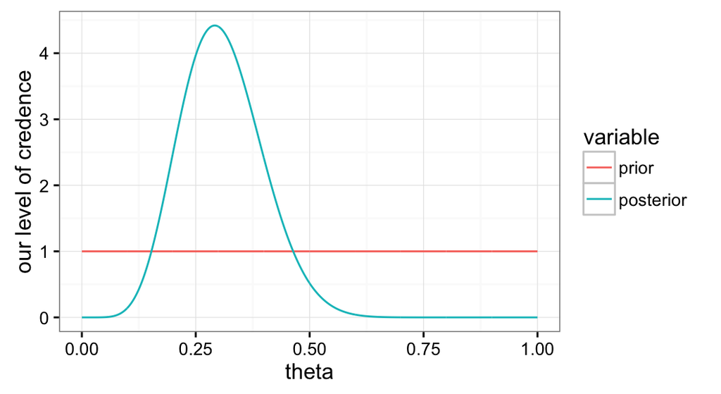

## "Classical statistics"

- null hypothesis significance testing (NHST)
  - e.g., is the coin fair (\(\theta = 0.5\))
- signals if the NH should be rejected
  - not: how likely it is or if it is to be accepted
- relies on sampling distributions & p-values
  - standard "tests" can have rigid built-in assumptions
  - implicitly rely on experimenter's intentions
- looks at point estimates only

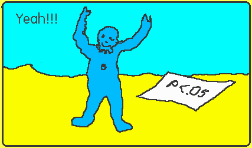

## Pros & Cons of BDA

### Pro

- well-founded & totally general
- easily extensible / customizable
- more informative / insightful

[figure not shown]

### Con

- less ready-made, thinking required
- not yet fully digested by community
- higher computational complexity

[figure not shown]

## 3 times Bayes

Bayesian data analysis - Bayesian analogues or alternatives to "classical" tests

Bayesian (cognitive) modeling - custom models of the data-generating process

Bayes in the head - model (human) cognition as Bayesian inference

## Goals of this course

- to understand basic ideas of BDA (contrast with NHST)
- to be able to read current literature on BDA
  - [further reading suggestions on BDA](http://michael-franke.github.io/KogWis2016_bda_tutorial/resources.html)
- to be able to start using tools for BDA
  - [pointers to useful tools for BDA](http://michael-franke.github.io/KogWis2016_bda_tutorial/tools.html)
  - there are also some (of course: optional) [exercises](http://michael-franke.github.io/KogWis2016_bda_tutorial/exercises.html)
- to see how BDA blends seamlessly into cognitive modeling

## The road ahead

theory

- posterior inference & credible values
- Bayes factors & model comparison
- comparison of Bayesian and "classical" NHST

practice

- basics of MCMC sampling
- tools for BDA ( JAGS, Stan (rstanarm), WebPPL, Jasp )
- Bayesian cognitive modeling example

## NHST & \(p\)-value logic

## binomial distribution

- take \(N\) flips of a coin with bias \(\theta\)
- binomial distribution gives the probability of observing \(k\) successes:

\[P(k \mid N, \theta) = {{N}\choose{k}} \, \theta^{k} \, (1-\theta)^{N - k}\]

- example: \(N=24\), \(\theta = 0.5\)

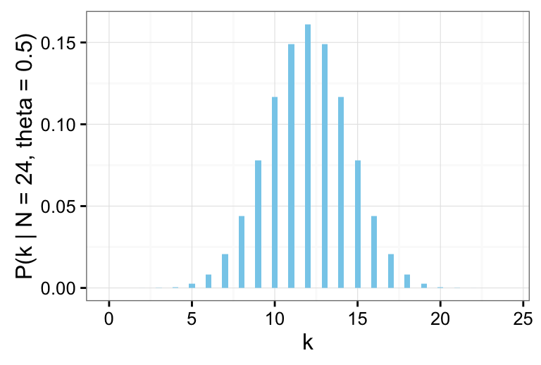

## NHST \(p\)-value logic

- we observed \(k=7\) successes after \(N=24\) flips
- null hypothesis: the coin is fair, i.e., \(\theta = 0.5\)
- the \(p\)-value of \(k=7\) is the probability of observing an outcome that is at least as unlikely as \(k=7\) under the NH in infinite repetitions of the experiment
- significance: reject NH if \(p\)-value is under a predetermined threshold (e.g., 0.05)

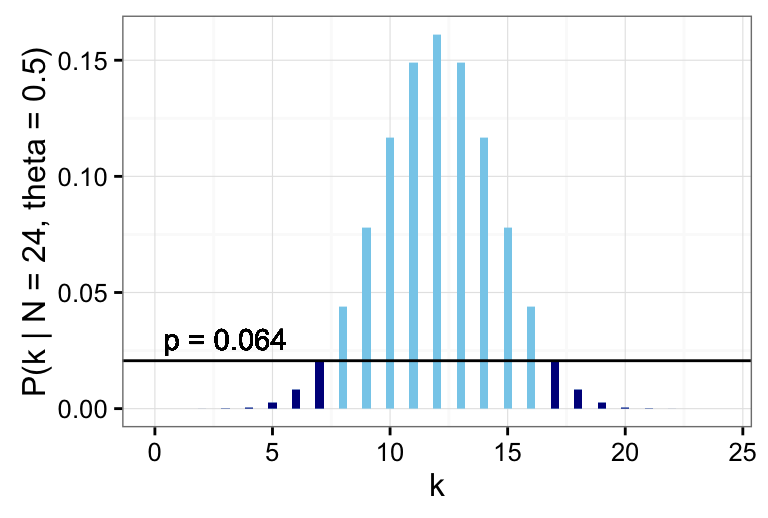

## negative binomial distribution

- flip a coin with bias \(\theta\) until we have observed \(k\) successes
- negative binomial distribution gives the probability of observing \(N\) flips:

\[P(N \mid k, \theta) = \frac{z}{N} \, {{N}\choose{k}} \, \theta^{k} \, (1-\theta)^{N - k}\]

- example: \(k=7\), \(\theta = 0.5\)

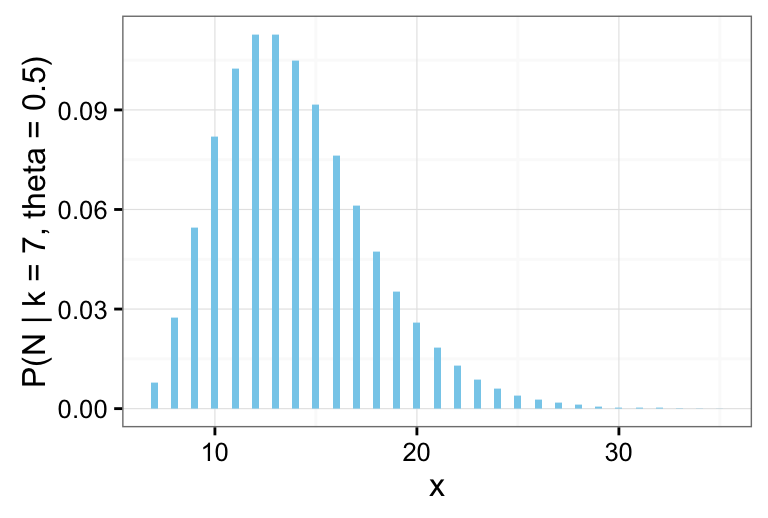

## another \(p\)-value for "same" data set

- we observed \(N=24\) flips for a success count of \(k=7\)
  - NB: same data set as before but obtained differently

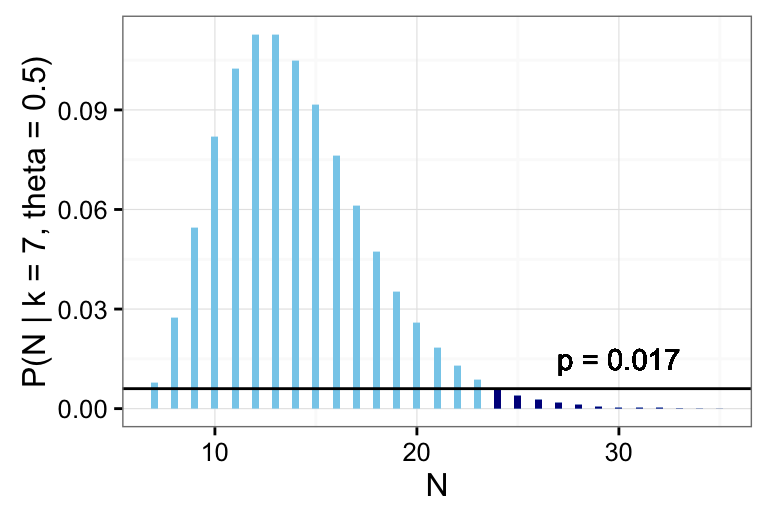

## some properties of \(p\)-value NHST

### intensional

- hinges on a what it means to repeat the experiment
  - "model" = data-generating (e.g., psychological) + data-collecting processes

## Bayesian basics

## key notions

conditional probability:

\[P(X \, | \, Y) = \frac{P(X \cap Y)}{P(Y)}\]

Bayes rule:

\[P(X \, | \, Y) = \frac{P(X) \times P(Y \, | \, X)}{P(Y)}\]

Bayes rule for data analysis:

\[\underbrace{P(\theta \, | \, D)}_{posterior} = \frac{\overbrace{P(\theta)}^{prior} \times \overbrace{P(D \, | \, \theta)}^{likelihood}}{\underbrace{P(D)}_{evidence}}\]

## Bayes rule in multi-D

joint probability distribution as two-dimensional matrix:

```
##       blond brown  red black
## blue   0.03  0.04 0.00  0.41
## green  0.09  0.09 0.05  0.01
## brown  0.04  0.02 0.09  0.13
```

marginal distribution over eye color:

```
##  blue green brown
##  0.48  0.24  0.28
```

conditional probability given black hair:

```
##  blue green brown
##  0.75  0.02  0.24
```

## model = prior & likelihood

model of a coin flip:

- bias parameter \(\theta \in \{0, \frac{1}{3}, \frac{1}{2}, \frac{2}{3}, 1\}\): probability of success on single trial
- flat prior beliefs: \(P(\theta) = .2\,, \forall \theta\)
- likelihood \(P(D \, | \, \theta)\) of data given \(\theta\):

```
##       t=0 t=1/3 t=1/2 t=2/3 t=1
## heads   0  0.33   0.5  0.67   1
## tails   1  0.67   0.5  0.33   0
```

weighing in \(P(\theta)\) gives joint-probability distribution as 2d matrix:

```
##       t=0 t=1/3 t=1/2 t=2/3 t=1
## heads 0.0  0.07   0.1  0.13 0.2
## tails 0.2  0.13   0.1  0.07 0.0
```

## Bayesian inference

Bayes rule: \(P(\theta \, | \, D) \propto P(\theta) \times P(D \, | \, \theta)\)

```
##       t=0 t=1/3 t=1/2 t=2/3 t=1
## heads 0.0  0.07   0.1  0.13 0.2
## tails 0.2  0.13   0.1  0.07 0.0
```

posterior probability \(P(\theta \, | \, \text{heads})\) after a toss with heads:

```
##   t=0 t=1/3 t=1/2 t=2/3   t=1
##  0.00  0.13  0.20  0.27  0.40
```

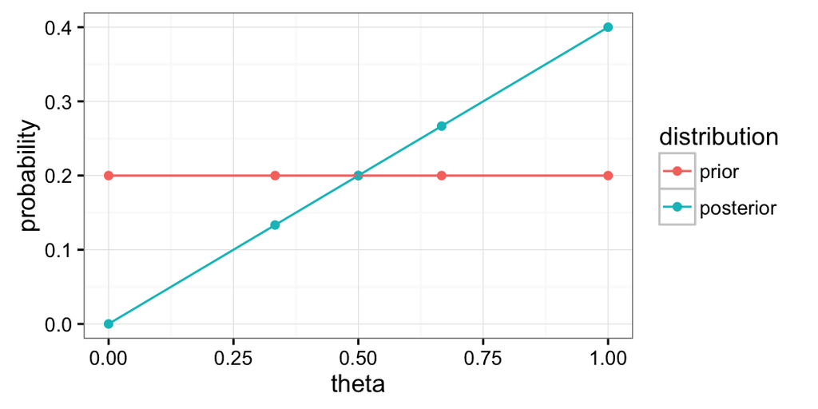

## generalized model of coin flips

- inifinite parameter space \(\theta \in [0;1]\)
- likelihood of observing \(k\) successes, given \(N\) flips, is binomial distribution:

\[P(k \mid N, \theta) = {{N}\choose{k}} \, \theta^{k} \, (1-\theta)^{N - k}\]

- example of a data-generating model:

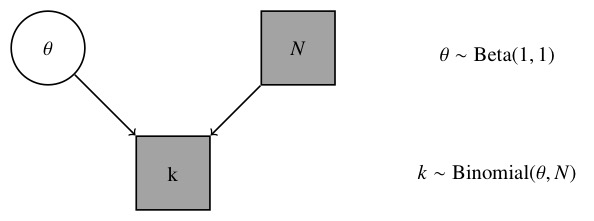

[see Lee & Wagenmakers ([2015](https://bayesmodels.com)) on conventions for graphical notation]

## examples

uniform prior: \(\theta \sim Beta(1,1)\)

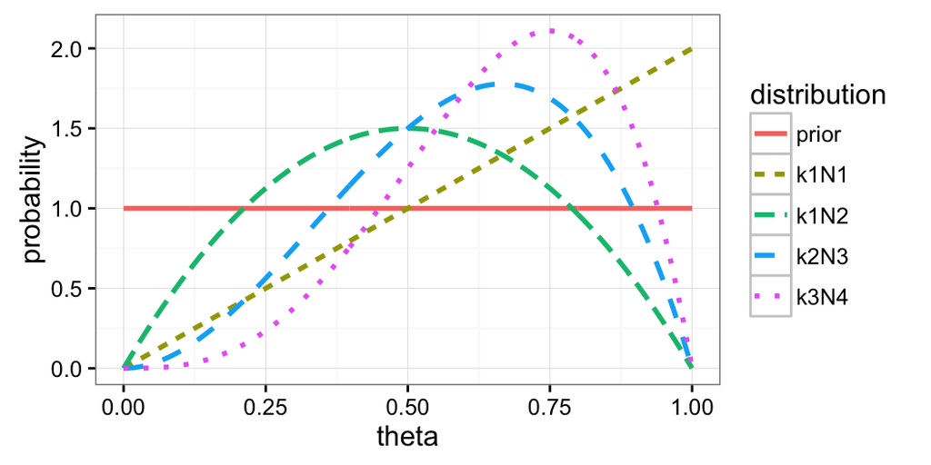

## examples

prior biased towards successes: \(\theta \sim Beta(7,3)\)

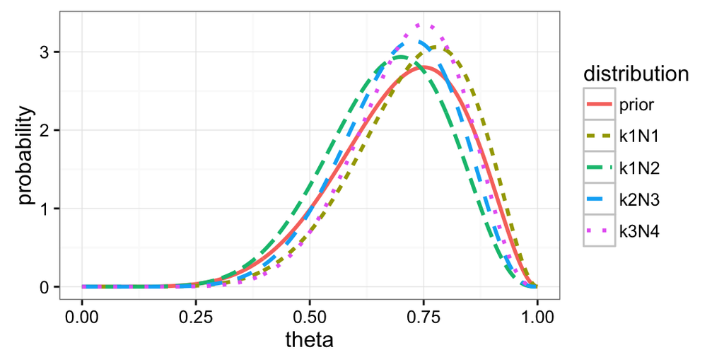

## examples

prior biased towards losses: \(\theta \sim Beta(3,7)\)

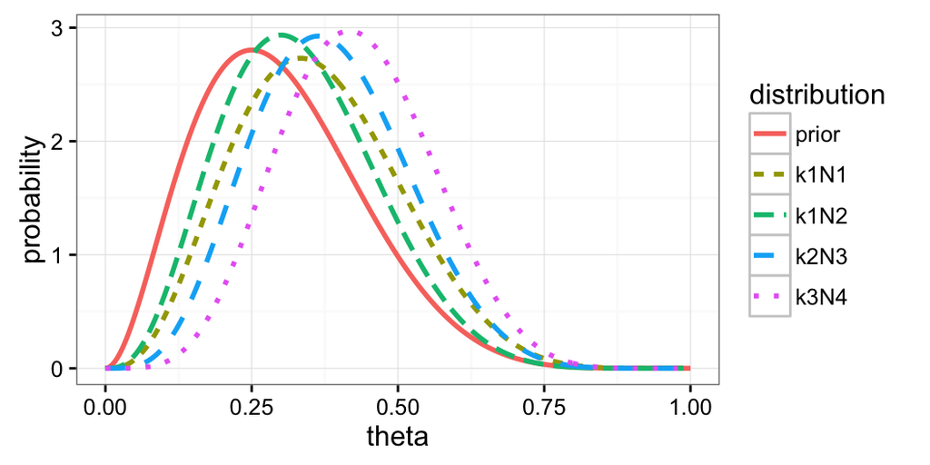

## independence of stopping rule

- \(P(\theta \mid D)\) is independent of stopping criterion during data collection
- any normalizing constant \(X\) cancels out:

\[ \begin{align*} P(\theta \mid D) & = \frac{P(\theta) \ P(D \mid \theta)}{\int_{\theta'} P(\theta') \ P(D \mid \theta')} \\ & = \frac{ \frac{1}{X} \ P(\theta) \ P(D \mid \theta)}{ \ \frac{1}{X}\ \int_{\theta'} P(\theta') \ P(D \mid \theta')} \\ & = \frac{P(\theta) \ \frac{1}{X}\ P(D \mid \theta)}{ \int_{\theta'} P(\theta') \ \frac{1}{X}\ P(D \mid \theta')} \end{align*} \]

## properties of Bayesian inference

### extensional

- independent of methods for data collection, as long as these do not influence \(P(D \mid \theta)\)

### doxastic

- is about subjective beliefs:
  - naturally interpretable
  - highly informative, distributional information
  - feeds directly into Bayesian decision theory

## estimation comparison criticism

## outlook

parameter estimation: what to conclude from the data given the model?

- maximum likelihood
- full Bayesian inference
- credible intervals

model comparison: which of several models is better?

- information criteria
- Bayes factors

model criticism: is my model any good?

- \(p\)-values
  - prior, posterior and classical
- posterior predictive checks

## preview

|  | estimation | comparison | criticism |
| --- | --- | --- | --- |
| goal | which \(\theta\), given \(M\) & \(D\)? | which better: \(M_0\) or \(M_1\)? | \(M\) good model of \(D\)? |
| method | Bayes rule | Bayes factor | \(p\)-value |
| no. of models | 1 | 2 | 1 |
| \(H_0\) | subset of \(\theta\) | \(P(\theta \mid M_0), P(D \mid \theta, M_0)\) | \(P(\theta), P(D \mid \theta)\) |
| \(H_1\) | — | \(P(\theta \mid M_1), P(D \mid \theta, M_1)\) | — |
| prerequisites | \(P(\theta), \alpha \times P(D \mid \theta)\) | — | test statistic |
| pros | lean, easy | intuitive, plausible, Ockham's razor | absolute |
| cons | vagueness in ROPE | prior dependence, computational load | sample space? |

## estimation

## credible interval

for distribution \(P(x)\) over \(X\), the \(n\)% credible interval is a subset \(Y \subseteq X\) such that:

1. \(P(Y) = \frac{n}{100}\), and
2. no point outside of \(Y\) is more likely than any point within

intuition: range of values we are justified to belief in (categorically).

[alternative terminology: highest density interval (HDI), credible region, …]

## examples

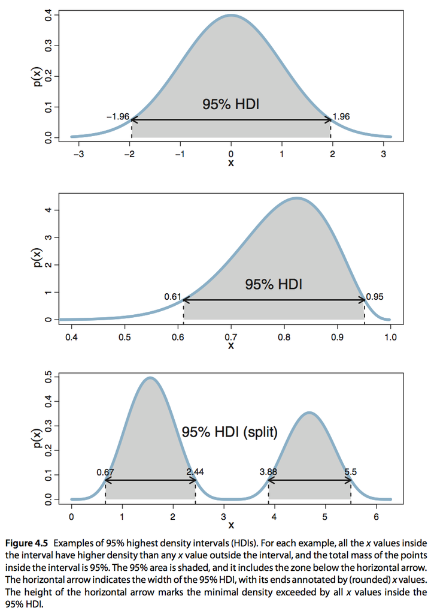

## posterior credible \(\theta\)'s

- observation: \(k = 7\), \(N = 24\)
- model:
  - \(\theta \sim Beta(1,1)\)
  - \(P(k) \sim Binomial(k,N)\)
- posterior: \(P(\theta \mid k=7, N = 24)\)

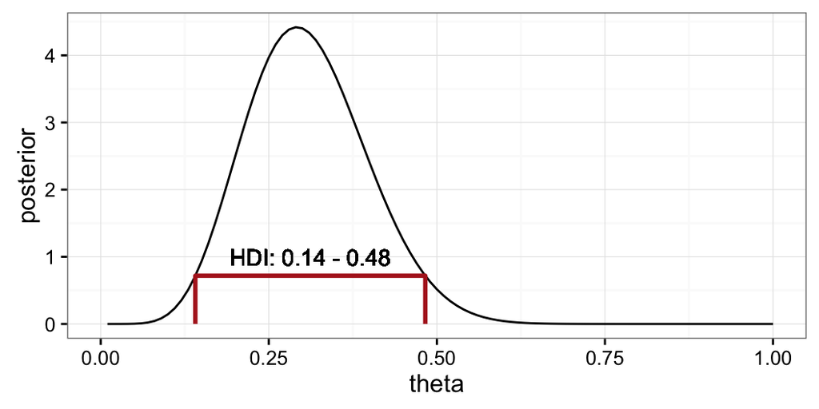

## ROPEs and credible values

### regions of practical equivalence (ROPE)

- small regions \([\theta - \epsilon, \theta + \epsilon]\) around each \(\theta\)
  - values (practically) indistinguishable from \(\theta\)

### credible values

- value \(\theta\) is rejectable if its ROPE lies entirely outside of posterior HDI
- value \(\theta\) is believable if its ROPE lies entirely whithin posterior HDI

[this is mainly Kruschke's ([2014](https://sites.google.com/site/doingbayesiandataanalysis/)) approach]

## model comparison

## model comparison

### main question

which model is better given data? (e.g., null model vs. alternative)

### caveat

different answers may imply different notions of "model" & purposes of modeling

## key notions

### information criteria

- maximum likelihood estimation
- free parameters
- model complexity

### Bayes factors

- Savage-Dickey method
- Lindley paradox

## Akaike information criterion

### motivation

- model is better, the higher \(P(D \mid \hat{\theta})\)
  - where \(\hat{\theta} \in \arg \max_\theta P(D \mid \theta)\)
- model is worse, the more parameters it has
  - principle of parsimony (Ockham's razor)
- information theoretic notion:
  - amount of information lost if we assume data generated by \(\hat{\theta}\)

### definition

let \(M\) be a model with \(k\) parameters, and \(D\) be some data:

\[\text{AIC}(M, D) = 2k - \ln P(D \mid \hat{\theta})\]

the smaller the AIC, the better the model

## model comparison by AIC

### example

```r
k = 7
N = 24
AIC_nh = - dbinom(k,N, prob = 0.5, log = T)
AIC_ah = 2 - dbinom(k,N, prob = k/N, log = T)
show(data.frame(model = c("null", "alt"),
                AIC = c(AIC_nh, AIC_ah) ))
```

```
##   model      AIC
## 1  null 3.881038
## 2   alt 3.732799
```

### weight of evidence

- let \(AIC_i\) be model \(i\)'s AIC & let \(\Delta_i = AIC_i - \min_j AIC_j\)
- weight of evidence for model \(i\) is: \(w_i \propto \exp(-0.5 \Delta_i)\)
- e.g., weight of evidence for alternative model is 1.077 (small!)

[e.g., Burnham & Anderson (2002)]

## remarks on information criteria

- given more and more data, repeated model selection by AIC does not guarantee ending up with the true model
- "model" for AICs is just likelihood; no prior
- not predictive, but "post-hoc" as \(\hat{\theta}\) depends on data
- discounting number of parameters, like AIC does, does not take effective strength of parameters into account
- there are other information criteria that address some of these problems:
  - Bayesian information criterion
  - deviance information criterion

## Bayes factors

- take two models (in the sense of "model = prior + likelihood")
  - \(P(\theta_1 , M_1)\) and \(P(D \mid \theta_1, M_1)\)
  - \(P(\theta_2 , M_2)\) and \(P(D \mid \theta_2, M_2)\)
- ideally, we'd want to know the absolute probability of \(M_i\) given the data
  - but then we'd need to know set of all models (for normalization)
- alternatively, we take odds of models given the data:

\[\underbrace{\frac{P(M_1 \mid D)}{P(M_2 \mid D)}}_{\text{posterior odds}} = \underbrace{\frac{P(D \mid M_1)}{P(D \mid M_2)}}_{\text{Bayes factor}} \ \underbrace{\frac{P(M_1)}{P(M_2)}}_{\text{prior odds}}\]

The Bayes factor is the factor by which our prior odds are changed by the data.

## evidence

Bayes factor in favor of model \(M_1\)

\[\text{BF}(M_1 > M_2) = \frac{P(D \mid M_1)}{P(D \mid M_2)}\]

evidence of model \(M_i\) (= marginal likelihood of data)

\[P(D \mid M_i) = \int P(\theta_i , M_i) \ P(D \mid \theta_i, M_i) \text{ d}\theta_i\]

evidence marginalizes out parameters \(\theta_i\): function of prior and likelihood

## example

- observed: \(k = 7\) out of \(N = 24\) flips came up heads
- goal: compare a null-model \(M_0\) with an alternative model \(M_1\)
- model specification:
  - \(M_0\) has \(\theta = 0.5\) and \(k \sim \text{Binomial}(0.5, N)\)
  - \(M_1\) has \(\theta \sim \text{Beta}(1,1)\) and \(k \sim \text{Binomial}(\theta, N)\)

\[ \begin{align*} \text{BF}(M_0 > M_1) & = \frac{P(D \mid M_0)}{P(D \mid M_1)} \\ & = \frac{\text{Binomial}(k,N,0.5)}{\int_0^1 \text{Beta}(\theta, 1, 1) \ \text{Binomial}(k,N, \theta) \text{ d}\theta} \\ & = \frac{ {{N}\choose{k}} 0.5^{k} \, (1-0.5)^{N - k}}{\int_0^1 {{N}\choose{k}} \theta^{k} \, (1-\theta)^{N - k} \text{ d}\theta} \\ & = \frac{0.5^{k} \, (1-0.5)^{N - k}}{BetaFunction(k+1, N-k+1)} \approx 0.516 \end{align*} \]

## how to interpret Bayes factors

| BF(M1 > M2) | interpretation |
| --- | --- |
| 1 | irrelevant data |
| 1 - 3 | hardly worth ink or breath |
| 3 - 6 | anecdotal |
| 6 - 10 | now we're talking: substantial |
| 10 - 30 | strong |
| 30 - 100 | very strong |
| 100 + | decisive (bye, bye \(M_2\)!) |

## how to caculate Bayes factors

1. calculate each model's evidence
   - brute force clever math
   - grid approximation
   - by MCMC estimation
2. calculate Bayes factor:
   - transdimensional MCMC
   - Savage-Dickey method

## properly nested models

- suppose that there are \(n\) continuous parameters of interest \(\theta = \langle \theta_1, \dots, \theta_n \rangle\)
- \(M_1\) is a model defined by \(P(\theta \mid M_1)\) & \(P(D \mid \theta, M_1)\)
- \(M_0\) is properly nested under \(M_1\) if:
  - \(M_0\) assigns fixed values to parameters \(\theta_i = x_i, \dots, \theta_n = x_n\)
  - \(\lim_{\theta_i \rightarrow x_i, \dots, \theta_n \rightarrow x_n} P(\theta_1, \dots, \theta_{i-1} \mid \theta_i, \dots, \theta_n, M_1) = P(\theta_1, \dots, \theta_{i-1} \mid M_0)\)
  - \(P(D \mid \theta_1, \dots, \theta_{i-1}, M_0) = P(D \mid \theta_1, \dots, \theta_{i-1}, \theta_i = x_i, \dots, \theta_n = x_n, M_1)\)

## Savage-Dickey method

let \(M_0\) be properly nested under \(M_1\) s.t. \(M_0\) fixes \(\theta_i = x_i, \dots, \theta_n = x_n\)

\[ \begin{align*} \text{BF}(M_0 > M_1) & = \frac{P(D \mid M_0)}{P(D \mid M_1)} \\ & = \frac{P(\theta_i = x_i, \dots, \theta_n = x_n \mid D, M_1)}{P(\theta_i = x_i, \dots, \theta_n = x_n \mid M_1)} \end{align*} \]

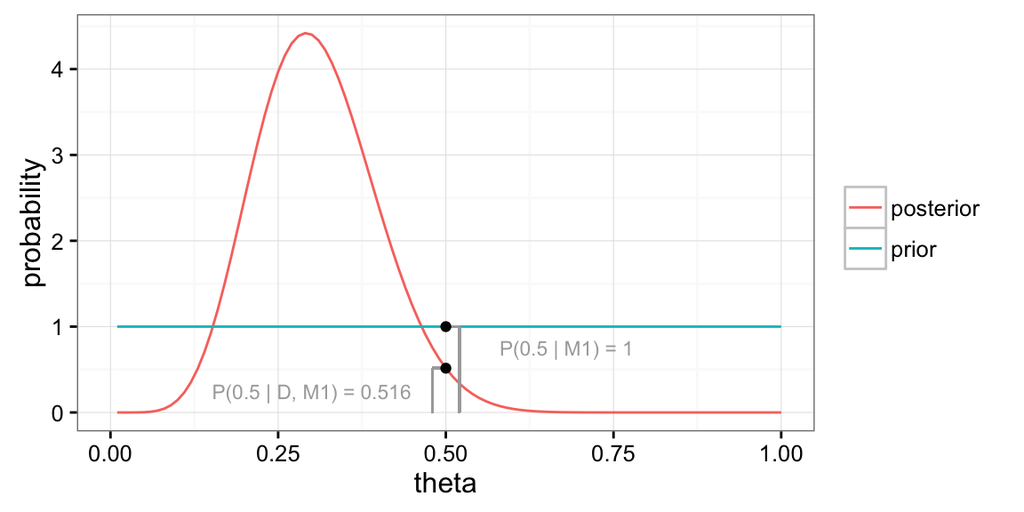

## recap

Bayes rule for parameter estimation:

\[\underbrace{P(\theta \, | \, D)}_{\text{posterior}} \propto \underbrace{P(\theta)}_{\text{prior}} \times \underbrace{P(D \, | \, \theta)}_{\text{likelihood}}\]

Bayes factor for model comparison:

\[ \begin{align*} \underbrace{\frac{P(M_1 \mid D)}{P(M_2 \mid D)}}_{\text{posterior odds}} & = \underbrace{\frac{P(D \mid M_1)}{P(D \mid M_2)}}_{\text{Bayes factor}} \ \underbrace{\frac{P(M_1)}{P(M_2)}}_{\text{prior odds}} \\ \underbrace{P(D \mid M_i)}_{\text{evidence}} & = \int P(\theta_i \mid M_i) \ P(D \mid \theta_i, M_i) \text{ d}\theta_i \end{align*} \]

\(p\)-values for null-hypothesis significance testing

## overview

|  | estimation | comparison | criticism |
| --- | --- | --- | --- |
| goal | which \(\theta\), given \(M\) & \(D\)? | which better: \(M_0\) or \(M_1\)? | \(M\) good model of \(D\)? |
| method | Bayes rule | Bayes factor | \(p\)-value |
| no. of models | 1 | 2 | 1 |
| \(H_0\) | subset of \(\theta\) | \(P(\theta \mid M_0), P(D \mid \theta, M_0)\) | \(P(\theta), P(D \mid \theta)\) |
| \(H_1\) | — | \(P(\theta \mid M_1), P(D \mid \theta, M_1)\) | — |
| prerequisites | \(P(\theta), \alpha \times P(D \mid \theta)\) | — | test statistic |
| pros | lean, easy | intuitive, plausible, Ockham's razor | absolute |
| cons | vagueness in ROPE | prior dependence, computational load | sample space? |

## comparison of approaches

## Jeffreys-Lindley paradox

```r
k = 49581
N = 98451
show(k/N)
```

```
## [1] 0.5036109
```

### \(p\)-value NHST

```r
binom.test(k, N)$p.value
```

```
## [1] 0.02364686
```

### Savage-Dickey BF

```r
dbeta(0.5, k+1, N - k + 1)
```

```
## [1] 19.21139
```

## simulation

- let the true bias be \(\theta = 0.5\)
- generate all possible outcomes \(k\) keeping \(N\) fixed
  - \(N \in \{ 10, 100, 1000, 10000, 100000 \}\)
  - true frequency of \(k\) is \(Binomial(k \mid N, \theta = 0.5)\)
- look at the frequency of test results, coded thus:

|  | estimation | comparison | criticism |
| --- | --- | --- | --- |
| \(M_0\) | \([.5-\epsilon, 0.5+\epsilon] \sqsubseteq\) 95% HDI or v.v. | BF(\(M_0\)>\(M_1\)) > 6 | \(p\) > 0.05 |
| \(M_1\) | \([.5-\epsilon, 0.5+\epsilon] \, \cap \,\) 95% HDI \(=\emptyset\) | BF(\(M_1\)>\(M_0\)) > 6 | \(p\) <= 0.05 |
| ?? | otherwise | otherwise | never |

## results

Bayes factor model comparison selects \(M_0\) correctly with probability 0.986 for \(N = 10000\), and with 0.996 for \(N = 100000\).

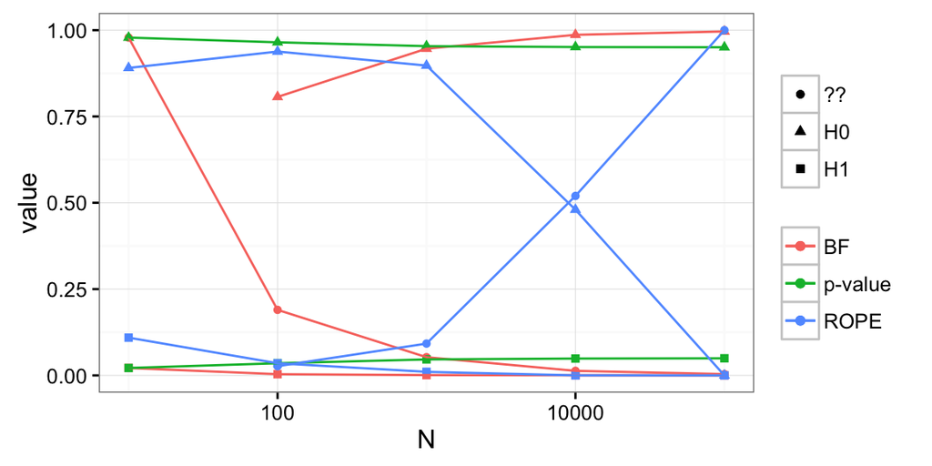

[c.f., Lindley's solution to 'paradox': adjust \(p\) depending on \(N\); similar for ROPE's \(\epsilon\)]

## wrap-up

## notions covered

- NHST \(p\)-value logic
- posterior inference
  - credible intervals, ROPE
- model comparison
  - Bayes factors